# Prepare mouse liver marker genes

Jaclyn Taroni for the CCDL

2021-06

We are going to identify clusters and marker genes in mouse liver data. We’ll obtain these data from the Human Cell Atlas. The data originally comes from [Ramachandran *et al.* 2019](https://doi.org/10.1038/s41586-019-1631-3).

([Here’s the HCA project itself!](https://data.humancellatlas.org/explore/projects/c41dffbf-ad83-447c-a0e1-13e689d9b258)) This study is [`PRJNA561303`](https://www.ebi.ac.uk/ena/browser/view/PRJNA561303) on ENA, but we will use the data from the HCA pipeline. We’re going to use the mouse data so folks have an opportunity to perform gene identifier conversion in another organism.

To quote the study description:

> We also present single-cell transcriptomic data on hepatic macrophages from healthy mice or mice following chronic carbon tetrachloride administration.

We’re using the Loom version of the [Optimus workflow](https://data.humancellatlas.org/pipelines/optimus-workflow) output.

## Download data from Human Cell Atlas

In this shell chunk, we’ll set up the data directory that will hold the loom file we get from the [Human Cell Atlas data portal](https://data.humancellatlas.org).

```bash
# data_dir=../../data/mouse-liver/loom
# mkdir -p ${data_dir}
# These links are set to expire, so this will not be totally reproducible
# wget --quiet -O ${data_dir}/healthy_cirrhotic_mouse_liver.loom "https://storage.googleapis.com/broad-datarepo-terra-prod-hca2-bucket/d30e68f8-c826-4639-88f3-ae35f00d4185/222d6d0f-f8d2-40ff-8dd2-cdbe4e6871f2/healthy-cirrhotic-mouse-liver-10XV2.loom?Expires=1624112964&GoogleAccessId=azul-ucsc-0-prod%40platform-hca-prod.iam.gserviceaccount.com&Signature=GVir14qK2YXORd1wvcfADI7BoDswufDzPGkX17JEQbg%2FIhxgSGQWJ1%2BJnv%2F3n%2FGYsBwJC%2BU0AfOBusCTAYR4YhqFsXop1tY%2Bl7ok4kHK3JCaZhvyXzhdCnuSOnN835r28yGK8vHtqJABjLGZvDAXVfHQlQAxFwgxH3a1LvyAA%2FfLBhLkrKbscdIb8uR07qDsuRSX6fdBYLNrcGltVsOO4ZDb7teEOYL0%2FydRLi%2F4epsXTnlWbf6Mv%2BrUBP36SiH5KWjWeD5ueW98L%2FcNwOL3%2FrlQs0GIHF%2FfTr6hII0NAT3NvQM3bEBqAAPlwOkIcxZv7sR2%2By1ML18N3Xo9kPewgw%3D%3D&response-content-disposition=attachment%3B+filename%3Dhealthy-cirrhotic-mouse-liver-10XV2.loom"
```

Based on this file name, we can anticipate that this includes cells from healthy and cirrhotic mouse livers.

## Set up

#### Libraries

```r
library(SingleCellExperiment)
library(magrittr)
```

#### Directories

```r
data_dir <- file.path("..", "..", "data", "mouse-liver")
loom_dir <- file.path(data_dir, "loom")

# Directory to hold filtered and normalized data
norm_dir <- file.path(data_dir, "normalized")
dir.create(norm_dir, recursive = TRUE, showWarnings = FALSE)

# We need tables of marker genes for the exercise
analysis_dir <- file.path("..", "..", "analysis", "mouse-liver")
markers_dir <- file.path(analysis_dir, "markers")
dir.create(markers_dir, recursive = TRUE, showWarnings = FALSE)

# Plots to be included in exercise - we'll put it in figures
plots_dir <- file.path("..", "..", "figures")
```

#### Files

```r
# Input
loom_file <- file.path(loom_dir, "healthy_cirrhotic_mouse_liver.loom")

# Output
# SCE with dim red results, cluster assignment, etc.
normalized_file <- file.path(norm_dir,
                             "healthy_cirrhotic_mouse_liver_normalized.rds")

# UMAP plot we'll include in the exercise
umap_file <- file.path(plots_dir, "mouse_liver_umap.png")
```

## Read in and process data

Per the HCA docs:

> The 10x matrices include raw counts

The assay in the loom object is called `matrix`, which will cause trouble so we rename it `counts`.

```r
# Read in and get SingleCellLoomExperiment
sce <- LoomExperiment::import(loom_file, type = "SingleCellLoomExperiment")

# The first assay matrix should be named "counts"
assayNames(sce)[1] <- "counts"

# Set the row and column names using included metadata
rownames(sce) <- rowData(sce)$Gene
colnames(sce) <- colData(sce)$CellID
```

### Filtering cells

There are already QC metrics associated with this object ([docs](https://data.humancellatlas.org/pipelines/qc-metrics))

```r
names(colData(sce))
```

```
 [1] "CellID"                                                 "antisense_reads"
 [3] "cell_barcode_fraction_bases_above_30_mean"              "cell_barcode_fraction_bases_above_30_variance"
 [5] "cell_names"                                             "duplicate_reads"
 [7] "emptydrops_FDR"                                         "emptydrops_IsCell"
 [9] "emptydrops_Limited"                                     "emptydrops_LogProb"
[11] "emptydrops_PValue"                                      "emptydrops_Total"
[13] "fragments_per_molecule"                                 "fragments_with_single_read_evidence"
[15] "genes_detected_multiple_observations"                   "genomic_read_quality_mean"
[17] "genomic_read_quality_variance"                          "genomic_reads_fraction_bases_quality_above_30_mean"
[19] "genomic_reads_fraction_bases_quality_above_30_variance" "input_id"
[21] "molecule_barcode_fraction_bases_above_30_mean"          "molecule_barcode_fraction_bases_above_30_variance"
[23] "molecules_with_single_read_evidence"                    "n_fragments"
[25] "n_genes"                                                "n_mitochondrial_genes"
[27] "n_mitochondrial_molecules"                              "n_molecules"
[29] "n_reads"                                                "noise_reads"
[31] "pct_mitochondrial_molecules"                            "perfect_cell_barcodes"
[33] "perfect_molecule_barcodes"                              "reads_mapped_exonic"
[35] "reads_mapped_intergenic"                                "reads_mapped_intronic"
[37] "reads_mapped_multiple"                                  "reads_mapped_too_many_loci"
[39] "reads_mapped_uniquely"                                  "reads_mapped_utr"
[41] "reads_per_fragment"                                     "reads_unmapped"
[43] "spliced_reads"
```

First, we’ll filter on the basis of the emptyDrops FDR.

```r
filtered_sce <- sce[, sce$emptydrops_FDR <= 0.01]
```

Then on the basis of % mitochondrial molecules.

```r
filtered_sce <- filtered_sce[, filtered_sce$pct_mitochondrial_molecules < 10]
```

We will get a few negative size factors if we don’t remove cells with few expressed features. We’ll filter on `n_genes` to account for this.

```r
filtered_sce <- filtered_sce[, filtered_sce$n_genes > 200]
```

### Filtering genes

```r
filtered_sce <- scater::addPerFeatureQC(filtered_sce)
# Genes detected more than 3% of cells
detected <- rowData(filtered_sce)$detected > 3
# Genes with mean count greater than 0.1
expressed <- rowData(filtered_sce)$mean > 0.1

filtered_sce <- filtered_sce[detected & expressed, ]
```

What did we retain with these cutoffs?

```r
dim(filtered_sce)
```

```
[1] 5805 8983
```

### Normalization

```r
# Set seed
set.seed(2021)

# Cluster similar cells
qclust <- scran::quickCluster(filtered_sce)

# Compute sum factors for each cell cluster grouping.
filtered_sce <- scran::computeSumFactors(filtered_sce,
                                         clusters = qclust,
                                         # Setting this to FALSE allows us to
                                         # do our own diagnostics if we get
                                         # negative size factors
                                         positive = FALSE)
```

Any negative size factors?

```r
any(filtered_sce$sizeFactor < 0)
```

```
[1] FALSE
```

Great, let’s normalize and transform our data.

```r
# Normalize and log transform.
normalized_sce <- scater::logNormCounts(filtered_sce)
```

Remove all the but the normalized `SingleCellExperiment`.

```r
rm(sce, filtered_sce)
```

## Clustering

### HVGs

Feature selection, e.g., identify high variance genes

```r
# Model gene variance
gene_variance <- scran::modelGeneVar(normalized_sce)
# Select the most variable genes
highvar_genes <- scran::getTopHVGs(gene_variance, n = 2500)
```

### PCA

Perform PCA on the high variance genes

```r
# Calculate and store PC matrix
normalized_sce <- scater::runPCA(normalized_sce, subset_row = highvar_genes)
```

Plot PC1 and PC2

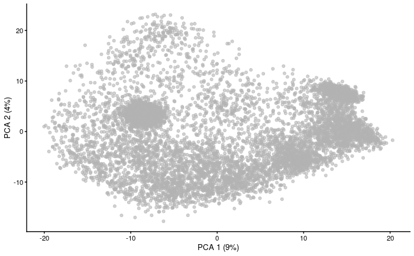

```r
scater::plotReducedDim(normalized_sce, "PCA")
```

### Clusters

We’ll perform clustering on the PCA matrix.

```r
# Extract the principal components matrix
pca_mat <- reducedDim(normalized_sce, "PCA")
```

Cluster the cells in PCA space, using graph-based clustering.

```r
# Run the clustering algorithm
nnclusters <- bluster::clusterRows(
  pca_mat,
  bluster::NNGraphParam(k = 10,
                        cluster.fun = "louvain")
)
# Store cluster results in the SCE object
normalized_sce$nncluster <- factor(nnclusters)
```

#### Visualize clusters

We’ll use UMAP for visualization here.

```r
# Run UMAP
normalized_sce <- scater::runUMAP(normalized_sce,
                                  dimred = "PCA")
```

And now for viz…

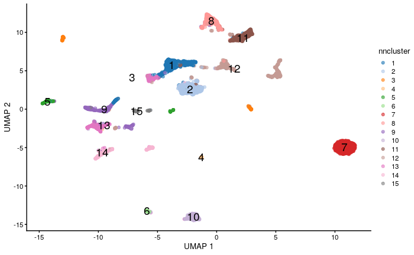

```r
scater::plotReducedDim(normalized_sce,
                       "UMAP",
                       colour_by = "nncluster",
                       text_by = "nncluster")
```

Save this plot to use in the exercise notebook itself.

```r
ggplot2::ggsave(umap_file, plot = ggplot2::last_plot())
```

Write the normalized and transformed object to file, complete with PCA, UMAP, and cluster labels. We will provide this RDS file during the training workshop.

```r
readr::write_rds(normalized_sce, file = normalized_file)
```

## Marker genes

Our main goal for this notebook is to obtain tables of marker genes for the exercise. We’ll use `pval.type = "all"` to mirror what we cover during instruction.

```r
markers <- scran::findMarkers(normalized_sce,
                              groups = normalized_sce$nncluster,
                              pval.type = "all")
```

Let’s take a look at the top gene rankings for cluster 7.

```r
head(markers[[7]], n = 10)
```

```
DataFrame with 10 rows and 17 columns
            p.value         FDR summary.logFC   logFC.1   logFC.2   logFC.3   logFC.4   logFC.5   logFC.6   logFC.8
          <numeric>   <numeric>     <numeric> <numeric> <numeric> <numeric> <numeric> <numeric> <numeric> <numeric>
Arg1    3.80659e-37 2.20972e-33      0.683780  0.777733 -1.591447  0.683780  0.814688  0.814958  0.782692  0.836513
Rpl35   8.14241e-36 2.36333e-32     -3.218588 -2.759794 -2.201371 -3.395184 -3.218588 -2.526663 -2.882619 -2.420462
Hbb-bs  8.65359e-28 1.67447e-24      1.133214  1.153364  1.102493  1.214971  1.133214  1.125423  1.151871  1.235125
Gm10736 5.10986e-26 7.41568e-23     -3.554239 -2.043253 -1.970320 -2.791170 -3.554239 -1.967324 -2.075621 -2.663723
Jchain  5.34314e-25 6.20339e-22     -5.287414  2.720909  2.717757  2.839673 -5.287414  2.775231  2.889872  2.708006
Gm10076 1.10795e-24 1.07194e-21     -2.941306 -1.648045 -1.588298 -2.220203 -2.941306 -1.531989 -1.642781 -1.866784
Vsig4   1.73503e-24 1.43883e-21      0.855394  0.721123  0.801672  0.925229  0.855394  0.897900  0.896265 -1.956760
Ftl1    1.40331e-23 1.01828e-20     -0.766025 -3.638347 -1.809020 -1.004925 -2.799993 -2.782265 -1.405517 -3.494395
Saa3    4.70139e-23 3.03240e-20      3.001811  2.919048  0.922090  3.443218  3.001811  2.980409  2.993339  3.716064
Gm3511  7.26967e-23 4.22005e-20     -3.001221 -2.949232 -2.900243 -3.585602 -3.001221 -2.961234 -3.356728 -2.628769
          logFC.9  logFC.10  logFC.11  logFC.12  logFC.13  logFC.14  logFC.15
        <numeric> <numeric> <numeric> <numeric> <numeric> <numeric> <numeric>
Arg1     0.822590  0.850172  0.761921  0.743770  0.822864  0.819154  0.837061
Rpl35   -3.217376 -3.136585 -1.470442 -1.023105 -3.434106 -3.505367 -3.039999
Hbb-bs   1.239325  1.248841  1.049269  1.152061  1.178704  1.205458  1.220123
Gm10736 -3.336052 -3.349643 -0.997019 -1.102456 -3.072193 -3.431978 -2.416674
Jchain   2.785910  2.790371  2.759640  2.724211  2.734685  2.736484  2.913916
Gm10076 -2.475170 -2.442041 -0.850240 -0.804251 -2.432976 -2.670619 -1.699558
Vsig4    0.787924  0.842971 -2.681603  0.717692  0.862408  0.800220  0.788624
Ftl1    -3.684106 -2.856179 -1.517952 -0.766025 -2.186741 -2.460626 -3.580386
Saa3     3.595494  3.749276  2.704492  2.861287  3.390834  3.526012  3.510470
Gm3511  -3.365066 -3.369449 -1.909465 -1.340126 -3.563981 -3.767970 -3.199554
```

Jchain has a small FDR value and negative summary log fold change; let’s take a look at the expression values in the UMAP plot.

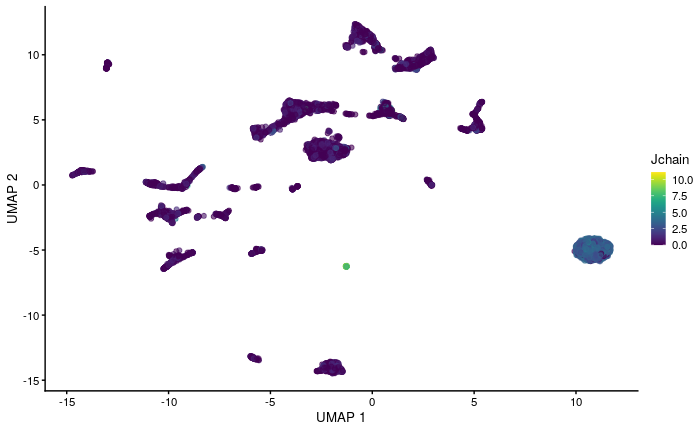

```r
# Plot UMAP results colored by expression
scater::plotReducedDim(normalized_sce, "UMAP",
                       colour_by = "Jchain")
```

Visually, it seems like Jchain has an above average expression value in cluster 7. Summary log fold change is a collapsing the effect sizes into a single (summarized!) value. This value will reflect the fold change value of the pairwise comparison with the largest p-value (e.g., weakest differential expression) ([ref](https://rdrr.io/bioc/scran/man/combineMarkers.html)). From the table and the plot, we can see that the negative summary log fold change and is equal to `logFC.4` is driven by the very high expression values for Jchain in cluster 4.

Saa3 has a positive summary log fold change, let’s take a look at the plot.

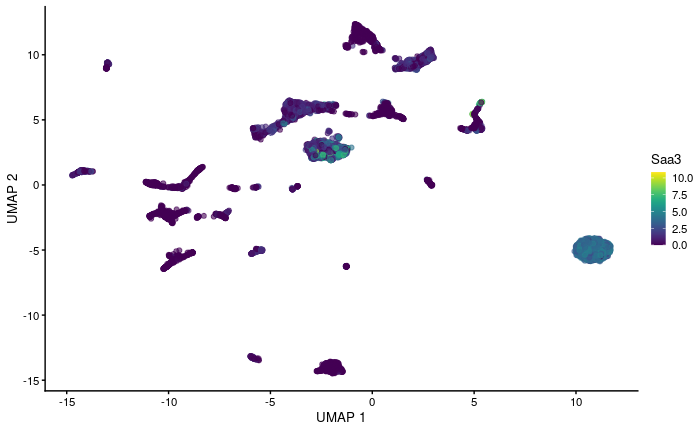

```r
# Plot UMAP results colored by expression
scater::plotReducedDim(normalized_sce,
                       "UMAP",
                       colour_by = "Saa3")
```

Though we see some individual samples with high expression values for Saa3 in cluster 2, it looks like it is most consistently highly expressed in cluster 7 and the cluster 2 comparison does not result in the largest p-value. (That distinction here, and for most of the top 10 genes, goes to cluster 4.)

Now we’re ready to write each table of marker genes, sorted by FDR, to file.

```r
purrr::iwalk(
  as.list(markers), # convert markers to a 'regular' list for purrr
  # purrr function: .x is the list element, .y is the element name (number here)
  ~ as.data.frame(.x) %>% # first convert to a data frame
    tibble::rownames_to_column("gene") %>% # make genes a column
    dplyr::arrange(FDR) %>% # sort to be sure small FDR genes are first
    readr::write_tsv( # write each data frame to a file
      file.path(markers_dir, # construct the output path
                sprintf("cluster%02d_markers.tsv", as.integer(.y)) # format cluster numbers in file names with leading zeros
      )
    )
)
```